# Lab 4b: Programming

## Content

1. Looping
2. Writing your own function

## Looping

## Loops

Iterates a set of commands multiple times

Loops are used for:

- simulation studies
- bootstrapping
- maximization of non-linear functions
- and solving many other problems

Loops save you a lot of typing and prevents making errors

## The `for` loop

The code

```r
for (counter in sequence) {

  expressions  # all axpression with curly brackets are executed

}
```

- `counter` variable that subsequently takes the values in the `sequence`
- `sequence` sequence of value that are used in the `expressions`
- `expressions` are executed as many times as the length of the `sequence`

## Example

Compute the exponents of the numbers 1 to 10

- in the 1st loop `i = 1`, in the 2nd `i = 2`, etc.
- the loop stops after `1 = 10`

```r
for (i in 1:10) {
  print(exp(i))
}
```

```
[1] 2.718282
[1] 7.389056
[1] 20.08554
[1] 54.59815
[1] 148.4132
[1] 403.4288
[1] 1096.633
[1] 2980.958
[1] 8103.084
[1] 22026.47
```

## Container objects

Object to store the results of each iteration in the loop

- has to be initialized before the loop starts
- matrices and lists are best suited for this

```r
out <- matrix(nrow = 10, ncol = 2, dimnames = list(1:10, c("x", "exp(x)")))
for (i in 1:10) {
 out[i, ] <- exp(i)
}
out
```

```
              x       exp(x)
1      2.718282     2.718282
2      7.389056     7.389056
3     20.085537    20.085537
4     54.598150    54.598150
5    148.413159   148.413159
6    403.428793   403.428793
7   1096.633158  1096.633158
8   2980.957987  2980.957987
9   8103.083928  8103.083928
10 22026.465795 22026.465795
```

## Plot example

Display `mpg` on y-axis and all other variables on the x-axis (`fig.asp=.35`)

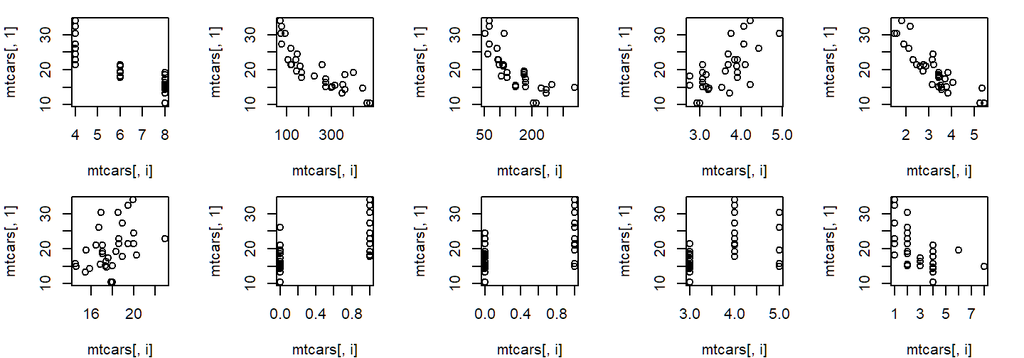

```r
par(mfrow = c(2, 5), mar = c(4, 4, 1, 2))
for (i in 2:11) {
  plot(x = mtcars[, i], y = mtcars[, 1])
}
```

## Adding the variable names

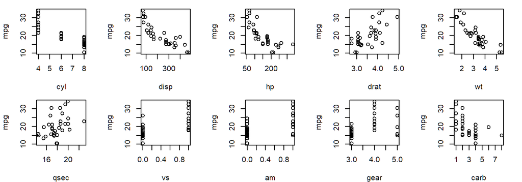

```r
vars <- colnames(mtcars)
par(mfrow = c(2, 5), mar = c(4, 4, 1, 2))
for (i in 2:11) {
  plot(x = mtcars[, i], y = mtcars[, 1], xlab = vars[i], ylab = vars[1])
}
```

## Other loop functions

R functions that perform loops over rows/columns of matrices/data frames

```r
apply(X, MARGIN, FUN)

sapply(X, FUN)
```

- `X` is name data frame / matrix
- `MARGIN` 1 = rows, 2 = columns
- `FUN` summary function that returns a statistic (e.g. `max`, `mean`, `var`, etc.)

For some applications easier to use than a loop

## Examples

Get the maximum value of each of the variable in `mtcars`

```r
sapply(mtcars, max)
```

```
    mpg     cyl    disp      hp    drat      wt    qsec      vs      am    gear    carb
 33.900   8.000 472.000 335.000   4.930   5.424  22.900   1.000   1.000   5.000   8.000
```

Get the `mean` in the rows of `mtcars` (silly example)

```r
apply(mtcars, 1, mean)
```

```
          Mazda RX4       Mazda RX4 Wag          Datsun 710      Hornet 4 Drive   Hornet Sportabout             Valiant          Duster 360
           29.90727            29.98136            23.59818            38.73955            53.66455            35.04909            59.72000
          Merc 240D            Merc 230            Merc 280           Merc 280C          Merc 450SE          Merc 450SL         Merc 450SLC
           24.63455            27.23364            31.86000            31.78727            46.43091            46.50000            46.35000
 Cadillac Fleetwood Lincoln Continental   Chrysler Imperial            Fiat 128         Honda Civic      Toyota Corolla       Toyota Corona
           66.23273            66.05855            65.97227            19.44091            17.74227            18.81409            24.88864
   Dodge Challenger         AMC Javelin          Camaro Z28    Pontiac Firebird           Fiat X1-9       Porsche 914-2        Lotus Europa
           47.24091            46.00773            58.75273            57.37955            18.92864            24.77909            24.88027
     Ford Pantera L        Ferrari Dino       Maserati Bora          Volvo 142E
           60.97182            34.50818            63.15545            26.26273
```

## `sapply` with function arguments

To return the 2.5% and 97.5% percentiles of the variables in `mtcars`

The function quantile returns percentile of vector `x` , e.g.

```r
quantile(x, prob = c(.025, .975))
```

Used in `sapply`

```r
sapply(mtcars, quantile, prob = c(.025, .975))
```

```
          mpg cyl    disp      hp   drat       wt    qsec vs am gear carb
2.5%  10.4000   4  74.665  59.750 2.7600 1.592050 14.5775  0  0    3 1.00
97.5% 32.7375   8 462.700 279.975 4.5425 5.362775 20.8230  1  1    5 6.45
```

## Writing functions

## Write your own function

The function is `function()`

```r
my_function <- function(arguments) {

  expressions

  return(output)

}
```

- `arguments` are input of the function
- `expressions` are operations performed on the arguments
- `output` an object containing the output (e.g. vector, matrix, list, etc.)
- `return` optional, the object `output` is sufficient

## Tossing a die

A function without arguments that simulates tossing a die

```r
die <- function() {

  eyes <- sample(1:6, size = 1)

  return(eyes)
}
```

```r
c(die(), die(), die())
```

```
[1] 3 6 3
```

## Defining an argument

The argument `n` specifies the number of dice to toss

```r
dice <- function(n) {

  return(sample(1:6, size = n, replace = TRUE))
}

dice(10)
```

```
 [1] 2 2 6 3 5 4 6 6 1 2
```

## Multiple returns

A function `dice(n)` returning a list with

- the outcomes of the `n` throws, their frequencies and their mean

```r
dice <- function(n) {

  eyes <- sample(1:6, size = n, replace = TRUE)

  return(list(outcomes = eyes,
              freqs    = table(eyes),
              mean     = mean(eyes)))
}
dice(10)
```

```
$outcomes
 [1] 3 5 3 3 1 4 1 1 5 3

$freqs
eyes
1 3 4 5
3 4 1 2

$mean
[1] 2.9
```

## Default arguments

The default is a fair die (each outcome has probability 1/6)

- the user can change this if so desired

```r
dice <- function(n, p = rep(1/6, 6)) {

  eyes <- sample(1:6, size = n, replace = TRUE, prob = p)

  return(list(outcomes  = eyes,
              frequency = table(eyes),
              mean      = mean(eyes)))
}
dice(100)
```

```
$outcomes
  [1] 5 5 3 2 1 1 6 6 2 4 6 3 3 3 2 4 4 4 2 2 3 4 3 1 2 4 6 2 5 3 2 6 1 4 5 2 4 3 6 4 6 6 6 4 6 5 6 2 4 3 4 5 4 2 3 6 4 6 2 4 1 1 1 3 2 5 4 5
 [69] 3 3 6 2 4 5 5 3 4 1 4 1 1 5 4 2 1 3 2 1 6 2 5 1 5 4 5 3 3 3 4 1

$frequency
eyes
 1  2  3  4  5  6
14 17 18 22 14 15

$mean
[1] 3.5
```

## Unfair dice

The following command throws 100 unfair dice

- probabilities 1, 2, 3, 4, 5 is 0.1
- probability of 6 is 0.5

```r
dice(100,  c(rep(.1, 5), .5))
```

```
$outcomes
  [1] 6 6 6 4 4 2 4 5 3 4 2 5 1 6 6 6 6 6 2 6 6 6 6 5 2 6 6 6 6 6 3 6 6 6 3 6 4 6 6 3 5 6 6 6 4 6 2 5 4 4 6 3 2 3 2 6 5 6 3 6 6 3 1 1 6 6 1 4
 [69] 1 6 6 4 6 3 6 1 4 3 6 2 6 6 6 6 6 6 6 4 6 5 6 6 2 1 6 1 5 4 6 6

$frequency
eyes
 1  2  3  4  5  6
 8  9 10 13  8 52

$mean
[1] 4.6
```

## Lab 4a